# Executive Summary

The objective of this project is to predict the manner in which participants performed a weight lifting exercise using accelerometer measurements. The response variable is `classe`, which contains five classes: A, B, C, D, and E.

A Random Forest classification approach was used. The data were cleaned by removing variables with excessive missing values, near-zero variance predictors, and identifier-related variables. A 70/30 stratified split was used for model evaluation and 5-fold cross-validation was used for model tuning.

# Data Loading

The training and testing datasets were loaded from the supplied CSV files.

```r
training <- read.csv("pml-training.csv", stringsAsFactors = FALSE)
testing <- read.csv("pml-testing.csv", stringsAsFactors = FALSE)

dim(training)
```

```
## [1] 19622   160
```

```r
dim(testing)
```

```
## [1]  20 160
```

# Data Cleaning

Variables containing more than 95% missing observations were removed.

```r
missing_percent <- colSums(is.na(training)) / nrow(training)

remove_missing <- names(
  missing_percent[missing_percent > 0.95]
)

training_clean <- training[
  , !(names(training) %in% remove_missing)
]

testing_clean <- testing[
  , !(names(testing) %in% remove_missing)
]
```

Near-zero variance predictors were removed.

```r
nzv <- nearZeroVar(training_clean)

if (length(nzv) > 0) {
  training_clean <- training_clean[, -nzv]
  testing_clean <- testing_clean[, -nzv]
}
```

Identifier, timestamp, and window-related variables were removed because they do not directly describe the physical movement being classified.

```r
remove_vars <- c(
  "X",
  "user_name",
  "raw_timestamp_part_1",
  "raw_timestamp_part_2",
  "cvtd_timestamp",
  "new_window",
  "num_window"
)

training_clean <- training_clean[
  , !(names(training_clean) %in% remove_vars)
]

testing_clean <- testing_clean[
  , !(names(testing_clean) %in% remove_vars)
]
```

The response variable was converted to a factor with five levels.

```r
training_clean$classe <- factor(
  training_clean$classe,
  levels = c("A", "B", "C", "D", "E")
)

predictor_names <- setdiff(
  names(training_clean),
  "classe"
)

testing_clean <- testing_clean[
  , predictor_names,
  drop = FALSE
]

dim(training_clean)
```

```
## [1] 19622    53
```

```r
dim(testing_clean)
```

```
## [1] 20 52
```

After cleaning, the training dataset contains **19,622 observations and 53 variables**, including the response variable. The testing dataset contains **20 observations and 52 predictors**.

# Exploratory Analysis

The distribution of the five outcome classes is shown below.

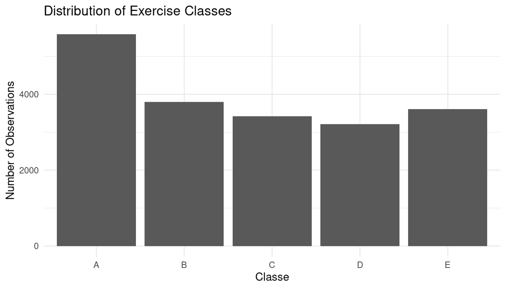

```r
class_data <- data.frame(
  classe = names(table(training_clean$classe)),
  count = as.numeric(table(training_clean$classe))
)

ggplot(
  class_data,
  aes(x = classe, y = count)
) +
  geom_col() +
  labs(
    title = "Distribution of Exercise Classes",
    x = "Classe",
    y = "Number of Observations"
  ) +
  theme_minimal()
```

All five classes are represented in the dataset, with class A being the most frequent.

# Model Development

A 70/30 stratified split was originally used to evaluate the model.

```r
set.seed(12345)

train_index <- createDataPartition(
  training_clean$classe,
  p = 0.70,
  list = FALSE
)

train_data <- training_clean[train_index, ]
validation_data <- training_clean[-train_index, ]

dim(train_data)
```

```
## [1] 13737    53
```

```r
dim(validation_data)
```

```
## [1] 5885   53
```

The training portion contained **13,737 observations**, while the validation portion contained **5,885 observations**.

A Random Forest model was selected because it can model nonlinear relationships and interactions among multiple accelerometer measurements.

Five-fold cross-validation was used during model development. The previously obtained cross-validation results were:

```r
cv_results <- data.frame(
  mtry = c(2, 27, 52),
  Accuracy = c(
    0.9915555,
    0.9915553,
    0.9840576
  ),
  Kappa = c(
    0.9893170,
    0.9893172,
    0.9798320
  )
)

kable(
  cv_results,
  digits = 4,
  caption = "Five-Fold Cross-Validation Results"
)
```

Five-Fold Cross-Validation Results

| mtry | Accuracy | Kappa |
| --- | --- | --- |
| 2 | 0.9916 | 0.9893 |
| 27 | 0.9916 | 0.9893 |
| 52 | 0.9841 | 0.9798 |

The best tuning value obtained during cross-validation was:

```r
best_mtry <- 2

best_mtry
```

```
## [1] 2
```

The selected value was **mtry = 2**.

# Validation Results

The previously obtained predictions on the independent validation set produced the following confusion matrix:

```r
confusion <- matrix(
  c(
    1673, 4,    0,   0,    0,
    1,    1135, 6,   0,    0,
    0,    0,    1020, 23,  0,
    0,    0,    0,   941,  1,
    0,    0,    0,   0,    1081
  ),
  nrow = 5,
  byrow = TRUE
)

rownames(confusion) <- c("A", "B", "C", "D", "E")
colnames(confusion) <- c("A", "B", "C", "D", "E")

kable(
  confusion,
  caption = "Validation Confusion Matrix"
)
```

Validation Confusion Matrix

|  | A | B | C | D | E |
| --- | --- | --- | --- | --- | --- |
| A | 1673 | 4 | 0 | 0 | 0 |
| B | 1 | 1135 | 6 | 0 | 0 |
| C | 0 | 0 | 1020 | 23 | 0 |
| D | 0 | 0 | 0 | 941 | 1 |
| E | 0 | 0 | 0 | 0 | 1081 |

The validation accuracy was:

```r
accuracy <- 0.9940527

out_of_sample_error <- 1 - accuracy

accuracy
```

```
## [1] 0.9940527
```

```r
out_of_sample_error
```

```
## [1] 0.0059473
```

The validation accuracy was approximately **99.41%**, corresponding to an estimated out-of-sample error of approximately **0.59%**.

Most of the observed classification errors occurred between classes C and D.

# Variable Importance

# Final Model

The final Random Forest model used the complete cleaned training dataset, with the tuning parameter selected through cross-validation.

The final model configuration was:

- Algorithm: Random Forest
- Number of trees: 500
- `mtry`: 2
- Training observations: 19,622